# The coconut palm

Malcolm Ross and Bethwyn Evans

## 1. Introduction

The products of the coconut palm are labelled by a complex terminology whose ancestry stretches back to Proto Oceanic (POc), a measure of their constant importance in the lives of Oceanic speakers.

## 2. The coconut palm

Growing to between 20 and 30m in height, coconut palms are found in profusion along coasts and on lowlands throughout the Oceanic-speaking region. They need well drained, sandy soil, more than 1000 mm rain per year and plenty of sunlight. Because they tolerate salinity, they often grow along beaches (French 1986: 31). Coconuts appear to have spread from southeast Asia both naturally (coconuts float) and anthropogenically (carried in the canoes of early settlers).[^1]

Just about every part of the palm and the fruit is used in traditional societies, and many of these parts are named. Because of the salience of the coconut in Oceanic cultures and because different uses are made of it at different stages of its growth, it is common for the fruit and palm to be given different names at different growth stages. These names are reconstructed in §3. Names for the parts of the fruit are reconstructed in §4 and for the parts of the palm other than the fruit in §5.

### 2.1. *Cocos nucifera*, coconut, TP, Bkokonas, P kokonat (Arecaceae)

POc *niuR appears to have been used in at least two senses: the fruit at any stage of growth, and the palm. A number of the glosses below are simply ‘coconut’: in all these cases the gloss almost certainly denotes both the fruit and the palm.

| **PMP** |  | *niuR | ‘coconut, *Cocos nucifera*; ripe coconut (growth stage of *Cocos nucifera*)’ (Dempwolff 1938) |
| --- | --- | --- | --- |
| **POc** |  | *niuR | ‘coconut palm and/or fruit, *Cocos nucifera*’ |
| Adm | Loniu | *niu* | ‘coconut’ (Nevermann 1934) |
| Adm | Titan | *niw* | ‘coconut, completely ripe’ |
| NNG | Kove | *niu* | ‘coconut’ |
| NNG | Numbami | *niwila* | ‘coconut’ |
| NNG | Kaiwa | *niuk* | ‘coconut’ |
| NNG | Lukep (Pono) | *(matuk) niu* | ‘green coconut’ |
| PT | Gapapaiwa | *niura* | ‘coconut’ |
| PT | Iamalele | *niula* | ‘coconut (tree, nut, meat)’ |
| PT | Tawala | *neula* | ‘coconut’ |
| PT | Sariba | *niu* | ‘coconut’ (archaic) |
| PT | Motu | *niu* | ‘coconut tree and mature fruit’ |
| MM | Bola | *niu* | ‘coconut’ |
| MM | Nalik | *nur* | ‘coconut’ |
| MM | Tabar | *niu* | ‘coconut’ |
| MM | Mono-Alu | *niunu* | ‘coconut’ |
| TM | Buma | *luro* | ‘coconut’ |
| TM | Nebao | *na-nə* | ‘coconut’ |
| TM | Asumboa | *u-ñio* | ‘coconut’ |
| TM | Tanibili | *no-ñio* | ‘coconut’ |
| SES | Gela | *niu* | ‘coconut palm, nut’ |
| SES | Kwaio | *niu* | ‘coconut’ |
| SES | Sa’a | *niu* | ‘coconut’ |
| NCV | Nokuku | *niu* | ‘coconut’ |
| NCV | Raga | *niu* | ‘coconut’ |
| NCV | Uripiv | *ne-ni* | ‘coconut’ |
| NCV | Paamese | *a-nii* | ‘green coconut w. soft flesh’ |
| NCV | Lewo | *niu* | ‘green drinking nut’ |
| NCV | South Efate | *na-niu* | ‘coconut’ |
| NCal | Nêlêmwâ | *nu* | ‘coconut’ |
| NCal | Iaai | *(wa)nu* | ‘coconut’ |
| NCal | Xârâcùù | *nũ* | ‘coconut’ |
| Mic | Kiribatese | *nii* | ‘coconut’ |
| Mic | Kosraean | *nu* | ‘coconut’ |
| Mic | Mokilese | *ni* | ‘coconut’ |
| Mic | Marshallese | *niy* | ‘coconut’ |
| Mic | Ponapean | *nī* | ‘coconut’ |
| Mic | Woleaian | *lǖ* | ‘coconut’ |
| Mic | Puluwatese | *nɨ̄* | ‘coconut’ |
| Mic | Trukese | *nɨ̄* | ‘coconut’ |
| Fij | Wayan | *niu* | ‘coconut palm, nut’ |
| Pn | Tongan | *niu* | ‘coconut palm, nut’ |
| Pn | Tikopia | *niu* | ‘coconut palm, nut’ |

## 3. Growth stages of the coconut

Right across Oceania, languages distinguish a number of growth stages of a coconut. These terminologies are often not cognate, but roughly agree on the semantic categories they distinguish.[^2] Sometimes a term for a growth stage becomes the generic term for coconut. For example, Lukep (Pono) (NNG) *matuk* and Mota (NCV) *matig*, both ‘coconut (generic)’ and reflexes of POc *matuqu ‘ripe coconut’, have displaced the reflex of POc *niuR ‘coconut (generic)’.[^3]

The growth stages are distinguished according to the states of the various parts of the fruit (Figure 12.1, p.369). At and after its drinkable stage, a coconut consists of a hollow shell (the endocarp) lined with flesh (the endosperm) and filled with coconut water. The shell is surrounded by a thick husk (the mesocarp) composed of fibres (coir) and enclosed by an outer skin (the exocarp ).[^4] The shell has three germination pores that are visible on the shell once the husk is removed. It is through one of these that the radicle emerges when the embryo germinates.

### 3.1. Growth stage terminologies

In the Oceanic view of the coconut’s life cycle, the first stage is the formation of the tiny fruit from the bud. The fruit then acquires liquid, then soft flesh, and becomes a green drinking coconut. The main reason to pick the nut at this stage is to drink its water: a big nut contains up to one litre. As it matures, the outer skin turns from green to brown, and the flesh becomes harder and thereby suitable for scraping as a food ingredient and for wringing to produce coconut ‘milk’ or ‘cream’ (vol.1, ch.6, §5.8, and ch.9, §2.2 and §7). The liquid becomes less and less drinkable. At this stage the coconut falls from the tree, the liquid solidifies into a spongy mass (the ‘apple’) and finally, given appropriate circumstances, germination occurs and the coconut sprouts to become a new palm. This contrasts markedly with a botanist’s view of the coconut’s life cycle (e.g. M. Foale 2003: 43–50), which begins with germination, describes the stages of leaf production and culminates in flowering and fruiting. The botanist’s view focusses on the palm, the Oceanic view on the fruit.

The first three terminologies, for Gumawana, Petats and Arosi, have sets of terms that are distributed across the fairly obviously recognisable growth stages of the coconut.

| Gumawana (PT): | 9 stages |
| --- | --- |
| *asipu* | ‘very small, not drinkable’ |
| *gavi* | ‘a bit bigger, not drinkable’ |
| *mosali* | ‘bigger, not drinkable’ |
| *bosibosi* | ‘large green, drinkable’ |
| *nakulamata* | ‘starts turning brown’ |
| *nugomoyao* | ‘brown but has not fallen yet’ |
| *nadada* | ‘dry and will fall’ |
| *nadaiyada* | ‘dry and fallen’ |
| *tabona* | ‘sprouted’ |

| Petats (MM): | 11 stages (Blackwood 1935: 310) |
| --- | --- |
| *teo* | ‘very young nut’ |
| *pesis*, *peli* | ‘young nut before it contains liquid’ |
| *kakarut* | ‘nut containing liquid before flesh appears’ |
| *irabil* | ‘nut with thin flesh layer at the cn~amy stage (drinking coconut)’ |
| *kuvo* | ‘nut with meat a little firmer, also used for drinking’ |
| *rut* | ‘nut containing a little (bitter) liquid and thick flesh’ |
| *laŋ* | ‘nut, the flesh of which has hardened (dry cococut)’ |
| *pitor* | ‘mature nut, the outer skin of which is not yet dry’ |
| *tunun* | ‘nut, the kernel of which has become spongy’ |
| *tus*, *alaun* | ‘nut which has become dry and fallen to the ground’ |
| *hala* | ‘nut which has sprouted’ |

| Arosi (SES): | 12 stages (Fox 1978) |
| --- | --- |
| *ʔoraamai* | ‘the first bud of a coconut’ |
| *kopu* | ‘newly formed fruit’ |
| *poku* | ‘young nut’ |
| *poru* | ‘green nut’ |
| *pʷaruru* | ‘young green drinking nut’ |
| *ʔobu* | ‘drinking nut’ |
| *niu pʷaikari* | ‘a nut still containing liquid’ |
| *niu kokoru* | ‘nut with hard flesh already formed’ (lit. ‘coconut egg-white’) |
| *niu saramarai* | ‘dry nut’ |
| *doʔo* | ‘ripe, dark nut’ (lit. ‘black’) |
| *niu matere* | ‘fallen mature nut’ |
| *niu bʷaʔo* | ‘very young palm’ |

The order of the Mota items below is that given by Codrington & Palmer (1896: 84), except that we have added *vara*, not included among their growth stage terms. However, their definitions (scattered under the various entries in the dictionary) suggest that their sequencing may be wrong, as *pulutyar* and *pepeya* appear to belong before *vusa maremare* (see discussion in association with Table 12.1).

| Mota (NCV): | 14 stages (Codrington & Palmer 1896) |
| --- | --- |
| *wovaŋ* | ‘bud’ |
| *matmateɣapun* | ‘just set, like the eye of a yapun crab’ |
| *sutarara* | ‘shell just formed, liquid not yet drinkable’ (sus ‘breast’, tarara ‘never given birth’) |
| *mʷalu* | ‘young green coconut, liquid not yet drinkable’ |
| *ɣarake pʷarat* | lit. ‘fat of meat’ |
| *[vusa] ɣorɣor* | ‘enough meat to scrape aflter drinking’ (yor ‘scrape’) |
| *vusa* | ‘green coconut for drinking’ |
| *vusa maremare* | ‘nut with hard flesh’ (maremare ‘hard’) |
| *vusa sisis* | ‘flesh can be scraped with a thumbnail’ |
| *pulut-ɣar* | ‘ripening, flesh sticks to scraper’ (lit. ‘stick.to scrape’) |
| *pepeɣa* | ‘outer skin turning yellow’ (pepeya ‘yellow’) |
| *pane uwa* | lit. ‘turtle fin’ [^6] |
| *kor* | ‘ready to fall’ (kor ‘become dry, with heat or time’) |
| *vara* | ‘a sprouting coconut’ |

Anejom and Tikopia also recognise respectively three and four stages of sprouted coconut, but it can be argued that these are growth stages of the palm, not of the fruit. The other languages may have corresponding terms that are not listed as coconut growth stages.

| Anejom (SV): | 11 stages (Lynch 2001c) |
| --- | --- |
| *nacomʷ* | ‘flower’ |
| *nohowa-nhuau* | ‘very small coconut’ (lit. ‘fruit a.boil’) |
| *inhivañereri* | ‘green coconut with very soft flesh’ |
| *inhivañwou* | ‘green coconut with drinkable water’ |
| *inhivañ* | ‘green coconut for drinking’ |
| *inhivañɣai* | ‘green coconut with edible flesh, almost ripe’ (lit. ‘fruit tree’) |
| *neañ metou* | ‘yellowish coconut’ (lit. ‘coconut ripe’) |
| *inhamesei*, *neañ mesei* | ‘dry coconut’ (lit. ‘coconut dry’) |
| *nelaneañ* | ‘germinated coconut or its pith’ |
| *neañθel* | ‘sprouting coconut’ (lit. ‘coconut grows (v)’) |
| *nerenren* | ‘sprouting coconut, longer sprout than neafiBel’ |

| Wayan Fijian (Fij): | 7 stages (Pawley & Sayaba 2003) |
| --- | --- |
| *bū takeri* | ‘very small coconut’ (lit. ‘fruit a.boil’) |
| *sula* | ‘immature stage, before flesh has formed; full of liquid’ |
| *bū* | ‘coconut at a stage ideal for drinking and eating; still green but full-sized, flesh well developed and soft’ |
| *bū ðiði-vutovuto* | ‘stage between bu and drokai’ (lit. ‘drinking.coconut flesh.removed-flooded’, i.e. a bu which still has liquid but the flesh of which is hardening; A. Pawley, pers. comm.) |
| *drokai* | ‘stage of late maturity; meat is hardening but still good to eat; juice becoming acidic’ |
| *sama* | ‘fully mature, old, a stage when no juice is left inside the nut and the flesh is oily and no longer edible but ready to be dried for copra or to be grated and squeezed to obtain coconut cream’ |
| *vara* | ‘ripe coconut, germinating; spongy flesh in kernel of ripe coconut’ |

| Tikopia (Pn): | 11 stages (Firth 1985) |
| --- | --- |
| *foi kārekāre* | ‘very young with soft shell’ (joi classifier, karekare ‘very young plant’) |
| *niu mata kaere* | ‘young with soft shell and flesh barely formed’ (lit. ‘coconut unripe very.young’) |
| *niu mata [laui]* | ‘green, with a firm shell and soft flesh’ (lit. ‘coconut unripe [good]’) |
| *niu motomoto* | ‘fully grown with hard flesh’ |
| *niu ŋaruru kiki* | ‘the liquid splashes around inside’ |
| *niu matua laui* | ‘mature with fully developed flesh’ (lit. ‘coconut mature good’) |
| *niu pakuku* | ‘dry, with darkened husk, last edible stage, fit for storage’ (lit. ‘coconut parched’) |
| *niu somo* | ‘germinated, beginning 1to sprout’ (lit. ‘coconut sprouts (v)’) |
| *niu matatiri* | ‘germinated, with a short sprout’ |
| *niu kapakau maroro* | ‘germinated, with shoots of about 30 em’ (lit. ‘coconut fins flying.fish’) |
| *niu raurau* | ‘germinated, with shoots of about 50 em’ (lit. ‘coconut leafy’) |

Two intermediate growth stages are of particular importance to coconut consumers: the stage when the coconut is maximally drinkable, and the stage when the flesh is hardened enough to allow scraping for the production of coconut ‘milk’. Not surprisingly, terms for these stages occur in every terminology. These are the two stages for which Tok Pisin of Papua New Guinea has distinct terms: *kulau* (from Ramoaaina) and *drai*.

Table 12.1 Rough comparison of coconut growth stage terms in seven Oceanic languages

|  | Gumawana | Petats | Arosi | Mota | Anejom | Wayan Fijian | Tikopia |
| --- | --- | --- | --- | --- | --- | --- | --- |
| 1. coconut fruit bud |  |  | • | • | • |  |  |
| **2. very small newly formed fruit** | • | • | • | • | • | • | • |
| 3. young, green, no liquid yet | • | • | • |  |  |  |  |
| 4. young, green, liquid but no flesh yet | • | • | • | ••• |  | • |  |
| 5. green, drinkable, very soft flesh |  |  | • | • | • |  | • |
| **6. green, drinkable, with thin creamy flesh** | • | • | • | • | •• | • | • |
| 7. starts turning brown, flesh firmer, still drinkable | • | • | • |  | • | • | •• |
| 8. little (bitter) liquid, thick flesh |  | • | • |  | • | • | • |
| **9. ripe, flesh hardened** | • | • | • | ••• | • | • | • |
| 10. dry and ready to fall | •• | •• | • | •• |  |  |  |
| 11. dry, fallen |  | • | • |  |  |  |  |
| **12. sprouted** | • | • | • | • | ••• | • | •••• |

Interestingly, two other stages have a term in all seven languages and in all terminologies we have examined: they are a term for the newly formed, tiny fruit and a term for the sprouted coconut. These are effectively the first and last stages in the life of the coconut (the bud is not yet a coconut).

| Tongan (Pn): | 11 stages (Churchward 1959) |
| --- | --- |
| *po-niu* | ‘newly formed coconut’ |
| *niu ŋono* |  |
| *niu mata-gono* |  |
| *niu mata-velivali* | ‘green, unripe’ |
| *niu mata* | ‘green drinking coconut’ |
| *niu mata-hihiloku* |  |
| *niumata-motomoto* |  |
| *niu motomoto* | ‘not quite ripe’ |
| *niu motuʔu* | ‘quite ripe’ |
| *niu matasili* | ‘just beginning to sprout’ |
| *niu ʔuto* | ‘with a bigger sprout than niu mata-sili’ |

Thus we might expect to be able to reconstruct terms for the four landmark stages. This is broadly true, except that stage 2 terms are hard to reconstruct. Terms between the landmarks tend to involve descriptive modifiers, as seen in the literal translations of a number of Anejom and Tikopia terms, and these are easily replaced over time. A few are metaphorical, like Mota *matmateɣapun* ‘eye of a *ɣapun* crab’ and *pane uwa* ‘turtle fin’. New metaphors or descriptions are readily created by new generations of speakers, and we can be sure of little else than that some POc terms must also have been metaphorical or descriptive.

The Gumawana, Petats and Arosi terminologies above include no binomials (setting aside Arosi *niu* ‘coconut’). If our account is correct, we would expect to find that the terms between the landmarks in these terminolgoes also reflect earlier descriptive terms, but we lack the relevant data to test this expectation.

Reconstructions for the four landmark stages, 2, 6, 9 and 12, are presented first below.

### 3.2. Growth stage 2: very small newly formed fruit

Two weakly supported etyma, POc *(q)a-bʷaji and PEOc *kiripʷa, can be offered for stage 2, ‘very small newly formed fruit’.[^8] The former may contain the root *bʷaji, which also occurs in POc *bʷaji-bʷaji ‘coconut growth stage 4 or 5’ (§3.6).

| **POc** |  | *(q)a-bʷaji | ‘coconut growth stage 2: very small newly formed fruit’ |
| --- | --- | --- | --- |
| MM | Kara (East) | *vəbos* | ‘undeveloped coconut’ |
| SV | Kwamera | *(i)apʷas* | ‘small coconut, coconut fruit bud’ |

| **PEOc** |  | *kiripʷa | ‘coconut growth stage 2: very small newly formed fruit’ |
| --- | --- | --- | --- |
| SES | ’Are’are | *kiriwa* | ‘immature coconut’ |
| Mic | Mokilese | *kiripʷ* | ‘young coconut up to one inch in diameter’ |
| Mic | Ponapean | *kurupʷ* | ‘immature coconut before teaching the growth stage called *ūpʷ*’ |

### 3.3. Growth stage 6: green, drinkable

Two forms can be reconstructed for landmark stage 6, ‘green drinkable coconut with thin creamy flesh’. The first, POc *karut,[^9] has the best distributed support, but it is not as widely reflected as stage 9 terms, a fact that is surprising (and unexplained) in light of the salience of stage 6 in Oceanic cultures.

| **POc** |  | *karut | ‘coconut growth stage 6: green, drinkable’ |
| --- | --- | --- | --- |
| PT | Hula | *kalu* | ‘half ripened coconut’ |
| PT | Motu | *karu* | ‘young drinking coconut’ |
| PT | Lala | *alu-ʔalu* | ‘young drinking coconut’ |
| MM | Petats | *ka-karut* | ‘nut containing liquid before flesh appears’ (Blackwood 1935) |
| SES | Longgu | *ʔaru* | ‘a coconut ready to drink and eat’ |
| SES | ’Are’are | *aru* | ‘green drinking coconut’ |

The other term, *polo, is less well reflected. Glosses pointing to growth stage 6 occur only in southern New Ireland, and we cannot be sure what it denoted.

| **POc** |  | *polo | ‘coconut growth stage 6: green, drinkable’ (?) |
| --- | --- | --- | --- |
| Adm | Lou | *puɔl* | ‘coconut’ |
| MM | Barok | *polo* | ‘young drinking coconut’ |
| MM | Sursurunga | *pol* | ‘young drinking coconut’ |
| MM | Label | *polo* | ‘coconut water, young drinking coconut’ |
| MM | Siar | *polo* | ‘coconut water’ |

### 3.4. Growth stage 9: ripe, flesh hardened

Reconstructable terms for stage 9, ‘ripe, flesh hardened’, are POc *matuqu, POc *kulu and POc *maRaŋo. Reflexes of POc *matuqu have become the generic term for coconut in a number of languages, suggesting that in the minds of speakers it is this stage that is prototypical of the coconut. It is clearly the most useful, as the flesh is used for various culinary purposes.

| **PEMP** |  | *matu(qu) | ‘dry coconut’ (Blust 1978a) |
| --- | --- | --- | --- |
| **POc** |  | *matuqu | ‘coconut growth stage 9: ripe, flesh hardened’ |
| NNG | Lukep (Pono) | *matuk* | ‘coconut (generic)’ |
| NNG | Atui | *(ka)mutuk* | ‘ripe coconut’ |
| NNG | Roinji | *mutuɣo-na* | ‘ripe coconut’ |
| NNG | Matukar | *matiwa-n* | ‘ripe coconut’ |
| PT | Sariba | *matuli-na* | ‘ripe coconut, ready to fall’ (-li- < ?) |
| PT | Sudest | *matu* | ‘dry coconut’ |
| NCV | Mwotlap | *na-mtiɣ* | ‘coconut (generic)’ |
| NCV | Mota | *matiɣ* | ‘coconut (generic)’ |
| NCV | Ambae | *matui* | ‘coconut (generic)’ |
| NCV | Nokuku | *metui* | ‘coconut (generic)’ |
| NCV | Tape | *mətiu* | ‘ripe coconut’ |
| NCV | Big Nambas | *nᫀətu* | ‘ripe coconut’ |
| NCV | Avava | *(ani) met-met* | ‘dry coconut but not fallen’ |
| NCV | Port Sandwich | *marue* | ‘ripe coconut’ |
| NCV | Paamese | *matou* | ‘dry coconut’ |
| NCV | Lewo | *maru* | ‘coconut (generic)’ |
| SV | Ura | *na-mda* | ‘green, starting to dry’ |
| SV | Sye | *na-mte* | ‘ripe coconut’ |
| SV | Anejom̃ | *(neañ)metou* | ‘drinking coconut with hard flesh’ |
| NCal | Iaai | *o-mɨṭ* | ‘ripe, yellow’ |
| NCal | Xârâcùù | *nû-mʌtʌ* | ‘ripe coconut’ |
| Mic | Marshallese | *məcə(wipᵚ)* | ‘coconut, nearly ripe’ |
| Fij | Rotuman | *mafu* | ‘mature and hard (of wood), lumpy (ofpudding), ripe and hard (of coconuts)’ |
| Fij | Bauan | *madū* | ‘dry (of wood and mature coconuts)’ |
| Pn | Tongan | *(niu) motuʔu* | ‘coconut growth stage: ripe’ |
| Pn | East Futunan | *(niu) mataʔu* | ‘very ripe dry coconut’ |
| Pn | Takuu | *matuu* | ‘coconut growth stage: mature coconut’ |

The Fijian gloss below calls into question the gloss of POc *kulu. However, a reflex of this term has become the Araki generic for ‘coconut’, and this is something that happens quite commonly to terms for ripe coconut. The Kuni and Roro terms reflect *-r- or *-R-, not *-l-.

| **POc** |  | *kulu | ‘coconut growth stage 9: ripe, flesh hardened’ (French-Wright 1983) |
| --- | --- | --- | --- |
| MM | Tangga | *kulu* | ‘fully grown drinking coconut’ |
| NNG | Uvol | *kul-kuli* | ‘ripe coconut’ |
| SES | ’Are’are | *ʔuru-ʔuru* | ‘ripe coconut’ |
| SES | Sa’a | *ʔulu-ʔulu* | ‘ripe coconut’ |
| NCV | Araki | *holo* | ‘coconut’ |
| Fij | Bauan | *kulu-kulu* | ‘the youngest stage of the coconut’ |

cf. also:

| PT | Kuni | *ol-olo* | ‘ripe coconut’ |
| --- | --- | --- | --- |
| PT | Roro | *kuro-kuro* | ‘ripe coconut’ |

The reconstruction of POc *maRaŋo ‘coconut growth stage 9: ripe, flesh hardened (or stage 10: dry and ready to fall)’ entails a phonological problem. I assumed in vol. 2 (ch.7, §5.6) that reflexes of this term were cognate with reflexes of POc *[ma]raŋo ‘become withered (of vegetation)’, reconstructed by Osmond in vol. 1 (ch.5, §9.4). I assumed further that both reflected PMP *(ma)Raŋaw and that the POc form was *[ma]Raŋo, regularly reflecting the PMP form. As I noted in vol.2, this is problematic, as Southeast Solomonic reflexes of the form *raŋo* ‘be withered’ reflect POc *r, not *R.

On balance the data now available suggest that my assumption in vol. 2 was wrong, and that two POc reconstructions must be made: POc *[ma]raŋo ‘become withered (of vegetation)’, as reconstructed by Osmond, and *maRaŋo ‘coconut growth stage …’. Two pieces of data underlie this decision. The first is Baelelea (SES) *maleŋa* ‘coconut’, in which *-l-* reflects POc *-R-, contrasting with the SES items of the form *raŋo* ‘be withered’, reflecting POc *-r-. The second is the Tape pair *meaŋ* ‘green coconut’, probably reflecting POc *-R- as zero, and *maraŋ* ‘(of wood, leaves) dry’, probably reflecting POc *-r-.[^10] The data supporting both etyma are listed below. The Sursurunga item appears in both lists, as it appears to represent a conflation of the two etyma.

Other than the items mentioned in the previous paragraph, none of the items below is diagnostic of the difference between POc *-R- and *-r- except for Niuean and Samoan *maŋo* ‘dry’, and these reflect *-R- (with a zero reflex), not *-r- as their meaning would lead us to expect. Also noteworthy is the odd fact that PMP *(ma)Raŋaw ‘dry’ contains *-R- whilst the POc etymon of similar meaning contains *-r-. In both cases speakers seem to have conflated or confused the two etyma.

| **PMP** |  | *(ma)Raŋaw | ‘dry’ (Blust 1981b) |
| --- | --- | --- | --- |
| **POc** |  | *maRaŋo | ‘coconut growth stage 9: ripe, flesh hardened (or stage 10: dry and ready to fall)’ |
| NNG | Medebur | *meraŋu-ŋ* | ‘ripe coconut’ |
| NNG | Kairiru | *maraŋ* | ‘ripe coconut’ |
| MM | Meramera | *mala* | ‘ripe coconut’ |
| MM | Kara (East) | *məyaŋ* | ‘dry coconut’ |
| MM | Nalik | *maraŋ* | ‘ripe coconut’ |
| MM | Lihir | *malan* | ‘ripe coconut’ |
| MM | Barok | *maŋa* | ‘ripe coconut’ |
| MM | Susurunga | *maraŋ* | ‘(be) old, dry; (old) coconut with lots of meat and little milk’ |
| MM | Patpatar | *maraŋa* | ‘dry coconut’ |
| SES | Baelelea | *maleŋa* | ‘coconut’ |
| NCV | Naman | *(neni) meraŋ* | ‘ripe coconut’ |
| NCV | Neve’ei | *(nani) meraŋ* | ‘ripe coconut’ |
| NCV | Larëvat | *(nən) meraŋ* | ‘ripe coconut’ |
| NCV | Nese | *(nani) naraŋ* | ‘ripe coconut’ |
| NCV | Tape | *meaŋ* | ‘green coconut with flesh that has become hard and water that has begun to go fizzy’ (J. Lynch, pers. comm.) |

| **POc** |  | *[ma-]raŋo | ‘become withered (ofvegetation)’ (vol. 1, ch.5, §9.4) |
| --- | --- | --- | --- |
| Adm | Mussau | *malaŋo* | ‘dry’ |
| NNG | Manam | *maraŋo* | ‘dry, arid’ |
| MM | Susurunga | *maraŋ* | ‘(be) old, dry; (old) coconut with lots of meat and little milk’ |
| MM | Tolai | *ma-raŋa* | ‘withered, dry (leaves, husk, tree)’ |
| MM | Selau | *raŋo* | ‘dry’ |
| SES | Bugotu | *raŋo* | ‘wither (leaves, yam vines)’ |
| SES | Sa’a | *raŋo* | ‘be withered, dry (esp. yams when vine withers)’ |
| SES | Arosi | *raŋo* | ‘withered, dead (of grass, green boughs + )’ |
| NCV | Mota | *raŋo* | ‘become dried up in the course of nature’ |
| NCV | Tape | *məraŋ* | ‘(of wood, leaves) dry’ (J. Lynch, pers. comm.) |
| SV | Kwamera | *(kahi)mareŋi* | ‘turning brown’ |

cf. also:

| Pn | Niuean | *maŋo* | ‘dry (of wood, trees)’ |
| --- | --- | --- | --- |
| Pn | Samoan | *maŋo* | ‘dry up; be dry (of wood, clothes)’ |

### 3.5. Growth stage 12: sprouting

Growth stage 12, the sprouted coconut, is evidently strongly associated in Oceanic minds with the spongy mass (the ‘apple’) inside it - the coagulated remains of the coconut water, eaten as a delicacy in many parts of Oceania (Peekel 1984: 65). Terms for the spongy mass inside the sprouting nut are given in §4.3.

The cognate set below apparently reflects POc *tubuq ‘grow, swell’ (vol.1, ch.5, §9.2), with the added meaning ‘(plant) sprout’. Probably, as in Taboro *niu tubu-na*, the verb was used attributively with the term for coconut to denote growth stage 12.

| PT | Taboro | *(niu) tubu-na* | ‘sprouted coconut’ |
| --- | --- | --- | --- |
| PT | Motu | *tubu* | ‘sprouted coconut’ |
| PT | Roro | *kupu* | ‘coconut sprouted’ |
| NCV | Ambae | *tubu* | ‘germinated coconut or its pith’ |

| **POc** |  | *tabʷa | ‘coconut growth stage 12: sprouted’ |
| --- | --- | --- | --- |
| NNG | Ulau-Suain | *tabu-ñ* | ‘young drinking coconut’ |
| NNG | Ali | *tapu-ŋ* | ‘young drinking coconut’ |
| PT | Dobu | *tabʷa(-anuwa)* | ‘coconut sprouted’ |
| PT | Gumawana | *tabo* | ‘a shoot; flesh inside a coconut that has sprouted’ |
| PT | Gumawana | *tabo-na* | ‘coconut growth stage: coconut that has sprouted’ |
| NCV | Raga | *tabʷe(-laha)* | ‘coconut shell drinking cup’ |
| SV | Anejom̃ | *na-tpʷa(-neañ)* | ‘spongy mass formed in a coconut that has started to shoot’ |

cf. also:

| Pn | West Futunan | *tafa* | ‘coconut when meat has jellied and milk is still sweet’ |
| --- | --- | --- | --- |
| Pn | East Uvean | *tāfā* | ‘unripe coconut’ |
| Pn | Emae | *tāfā* | ‘very young coconut’ |
| Pn | Tikopia | *tāfā* | ‘coconut in developing stage with only water inside’ |

### 3.6. Other growth stages

Reconstructing the meanings of growth stage terms which fall between the landmarks is difficult, both because these meanings tend not to match precisely across languages and because the meanings tend to shift along the growth stage taxonomy over time. This is reflected in the vagueness of the glosses of the reconstructions in this section.

Three terms, POc *kubu, POc *bʷaji-bʷaji and PWOc *pʷiga, denoted a stage when the coconut is young and green, somewhere among stages 3, 4 and 5. In the set supporting POc *kubu the meanings of the Oceanic glosses vary from stage 2, ‘newly formed fruit’ (Arosi), to stage 9, ‘mature coconut with meat’ (Wuvulu). However, they point in the direction of a young coconut, and one that is younger than a typical drinking coconut.

| **PEMP** |  | *kupu | ‘very young coconut’ (ACD: *upu: ‘germinating coconut?’)[^11] |
| --- | --- | --- | --- |
| **POc** |  | *kubu | ‘coconut growth stage 3, 4 or 5: young and green’ (ACD: *umpu: ‘young coconut?’) |
| Adm | Wuvulu | *upu* | ‘mature coconut with meat’ (ACD) |
| Adm | Aua | *upu* | ‘young coconut’ (Blust 1978b: 131) |
| Adm | Seimat | *up* | ‘coconut’ (ACD) |
| MM | Solos | *kubo* | ‘young drinking coconut’ |
| MM | Petats | *kuvo* | ‘nut with meat a little firmer than the prototypical drinking coconut’ (see Petats terminology above) |
| MM | Tinputz | *(oē) kupū* | ‘green coconut with meat’ |
| MM | Roviana | *kubo(lokuhu)* | ‘very young coconut’ |
| SES | Longgu | *kobu* | ‘young coconut that has no meat, only water’ |
| SES | Arosi | *kopu* | ‘newly formed fruit’ (see Arosi terminology above; probably a borrowing from another SES language) |
| SES | Arosi | *ʔobu* | ‘drinking nut’ (see Arosi terminology above) |
| Mic | Kosraean | *uf* | ‘young coconut’ (ACD) |
| Mic | Ponapean | *ūpʷ* | ‘drinking coconut’ (ACD) |
| Mic | Mokilese | *upʷ* | ‘coconut stage, unripe, younger than a drinking coconut’ |

POc *bʷaji-bʷaji appears to have denoted either stage 4 (young, green, liquid but no flesh yet) or stage 5 (green, drinkable, very soft flesh), but it is not widely enough reflected for us to be sure.

| **POc** |  | *bʷaji-bʷaji | ‘coconut growth stage 4 or 5’ |
| --- | --- | --- | --- |
| Adm | Mussau | *pasi-pasi-na* | ‘young drinking coconut’ |
| PT | Gumawana | *bosi-bosi* | ‘large green drinkable coconut still on the tree’ |
| PT | Kilivila | *bʷai-bʷai* | ‘young drinking coconut’ |
| PT | Misima | *bʷal-bʷal* | ‘young coconut with water but no meat’ |
| PT | Sudest | *bʷadi-bʷadi* | ‘coconut’ |

Ross (1996d) suggested that the cognate set reflecting PWOc *pʷiga implied a stage 5 meaning ‘just drinkable’ because in both PT languages and Roviana we find the apparently independent semantic development in meaning to ‘drinking vessel’. The element *ku-* in Ramoaaina *ku-bika* occurs in coconut terms in a number of Meso-Melanesian languages, and it is evidently cognate with Nehan *ku* ‘coconut oil’. The prefixed element in the Muyuw and Dobu terms may or may not be cognate.

| **PWOc** |  | *pʷiga | ‘coconut growth stage 3, 4 or 5: young and green’ |
| --- | --- | --- | --- |
| PT | Suau (Daui) | *biga-biga-na* | ‘young drinking coconut’ |
| PT | Kilivila | *viga* | ‘cup, drinking vessel’ |
| PT | Muyuw | *(kʷa)vig* | ‘half coconut shell used as cup’ |
| PT | Dobu | *(ke)iga* | ‘cup’ |
| PT | Maisin | *vuga* | ‘cup’ |
| MM | Ramoaaina | *(ku)bika* | ‘coconut growth stage before a green drinking coconut’ |
| MM | Nduke | *bika* | ‘small green coconut’ |
| MM | Roviana | *piga* | ‘coconut shell used as a bottle’ |

In vol. 2 (ch. 7, §5.6) POc *goRu ‘dry, of vegetation; coconut growth stage: dry and ready to fall’ was reconstructed. This gloss places a lot of weight on the Mota gloss: taken together the glosses suggest a stage 9 or 10 meaning, i.e. either ‘ripe’ or ‘dry and ready to fall’ . Lavukaleve, the non-Austronesian language of the Russell Islands (central Solomons) has *ŋgolus* ‘old dry coconut’ (Angela Terrill, pers. comm.), apparently borrowed from a NW Solomonic language that regularly retained POc final consonants. For this reason, we tentatively reconstruct POc final *-s here.

| **POc** |  | *[ma-]goRu(s) | ‘dry, of vegetation; coconut growth stage 9 or 10: ripe, perhaps dry and ready to fall’ (Ross 1996d) |
| --- | --- | --- | --- |
| NNG | Malai | *gor-gori* | ‘ripe coconut’ |
| NNG | Mamusi | *kolu-ŋana* | ‘ripe coconut’ |
| MM | Nakanai | *ma-golu* | ‘dried up, withered; of a coconut, dry enough to fall’ (A. Chowning, pers. comm.) |
| SES | Lengo | *golu* | ‘coconut flesh’ |
| NCV | Mota | *kor* | ‘coconut in its last condition before it falls from the tree; dry (of other things too)’ |
| NCV | Atchin | *kor* | ‘dry coconut’ |
| NCV | Uripiv | *(na-ni) kur* | ‘mature coconut (with firm meat and dry husk)’ |

## 4. Parts of the coconut fruit

Terms for coconut parts are divided here into parts of the fruit (this section) and parts of the palm (§5). As we noted earlier *niuR denoted both the palm and the fruit. POc speakers evidently distinguished between them by calling the palm *puqun ni niuR, literally ‘trunk of coconut’) and the fruit *puaq ni niuR ‘fruit of coconut’, reflected in Bauan and Wayan Fijian as *vu ni niu* and *vua ni niu* and in Tongan as *fuʔu ni niu* and *foʔi niu* (ch.2, §7.1.3).

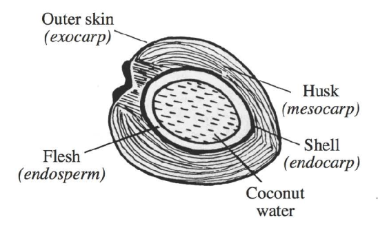

**Figure 12.1:** Parts of a coconut

In traditional times a palm bore between 5 and 30 coconuts a year, depending on the palm’s age.[^12] The usable parts of a coconut are related to its growth stages. At the green drinkable stage, the main usable product is the coconut water, although the thin flesh is sometimes eaten as a snack. At the ripe stage, when the flesh has thickened and hardened, the flesh is scraped and the scrapings are wrung out to give coconut milk, which is used in food, especially in stews. The husk of the ripe coconut is removed with a husking stick. Its mesocarp consists of densely matted dry fibres which have a variety of uses. Clean half-shells, with the flesh removed, are used as cups. At the sprouting stage, apart from use for planting a new palm, the main product is the ‘apple’, the edible sweet spongy mass that fills the shell cavity.

The fruit parts for which reconstructions are provided here are thus:

- coconut water (§4.1)
- hardened flesh and its products (§4.2)
- the ‘apple’ (§4.3)
- the husk (§4.4)
- the shell (§4.5)

### 4.1. Coconut water

POc *suRuq appears to have denoted drinkable liquids in general, including soups, but perhaps excluding plain water: its range clearly included coconut water. No more specialised designation for coconut water has been reconstructed, and it seems likely that the terms for a green drinking coconut (§3.3) were also used for the water inside it.[^13]

| **POc** |  | *suRuq | ‘sap, soup, drinkable liquid derived from plants, fruits or trees’ (Milke 1961: *suRu(q)) |
| --- | --- | --- | --- |
| Adm | Loniu | *cuy* | ‘soup’ |
| Adm | Titan | *sui* | ‘half-ripe coconut’ |
| NNG | Kove | *suhu* | ‘drinkable liquids; also tears, saliva’ (A. Chowning, pers. comm.) |
| NNG | Gitua | *suru* | ‘coconut water, soup’ |
| NNG | Gitua | *suru-suru* | ‘saliva’ |
| NNG | Bing | *sur* | ‘coconut water, soup’ |
| NNG | Manam | *suru* | ‘soup’ |
| NNG | Yabem | *sulu* | ‘soup’ |
| NNG | Yabem | *(awa)sulu* | ‘saliva’ (i.e. ‘sap of mouth’, *awa-* ‘mouth’) |
| NNG | Kaiwa | *ro-ruk* | ‘soup’ |
| NNG | Kaiwa | *(avo)rulu-* | ‘saliva’ (i.e. ‘sap of mouth’, *avo-* ‘mouth’) |
| PT | Dobu | *sulu* | ‘coconut water’ |
| PT | Molima | *sulu* | ‘coconut water’ |
| MM | Bali | *zuruka* | ‘coconut water’ |
| MM | Halia | *siru* | ‘soup’ |
| MM | Tinputz | *hun* | ‘coconut water’ |
| MM | Mono-Alu | *lulu* | ‘soup’ |
| SES | To’aba’ita | *sulu* | ‘juice, liquid of fruit; broth, sauce, gravy’ |
| SES | Arosi | *suru* | ‘coconut water; k.o. yam soup’ |
| NCV | Raga | *hu-* | ‘oil, liquid, juice, semen’ |
| NCV | Paamese | *sii-* | ‘juice’ |
| NCV | Nguna | *na-su(a)* | ‘coconut water, juice, soup’ |
| Pn | Samoan | *sū* | ‘be moist; (taro) be watery’ |
| Pn | Samoan | *su(a)* | ‘liquid, fluid; jouice; coconut milk; soup’ |

The weakly attested etymon POc *namo may have denoted ‘coconut water’ or a drinkable growth stage.

| **POc** |  | *namo | ‘coconut water’; ‘coconut growth stage: 3, 4 or 5: young and green’ |
| --- | --- | --- | --- |
| MM | Bulu | *namo* | ‘coconut water’ |
| MM | Bola | *namo* | ‘coconut water’ |
| NCV | South Efate | *namʷ* | ‘coconut growth stage: young, green, liquid but no flesh yet’ |

### 4.2. Coconut flesh and its products

When the coconut is ripe, the hardened flesh is either removed from the shell and cut up, or scraped from the shell using a coconut scraper. Scraping produces parings which are then squeezed to produce coconut milk.[^14]

The best candidate for ‘coconut flesh’ is POc *kanoŋ, a fossilised reflex of PMP *kan-en ‘something to be eaten, food’, itself a nominalisation of the PMP verb ‘eat’, *kaʔen, or *kan in the context of certain affixes. POc *kanoŋ had evidently lost its expected sense and denoted ‘flesh, inner substance, coconut flesh’. The morphology of POc nominalisations is discussed in vol.1 (ch.2, §3.2.1).[^15]

| **PMP** |  | *kan-en | ‘something to be eaten, food’ |
| --- | --- | --- | --- |
| **POc** |  | *kanoŋ | ‘flesh, inner substance, coconut flesh’ |
| NNG | Tuam | *anoŋa* | ‘seed, fruit’ |
| NNG | Malalamai | *anuŋa* | ‘coconut flesh’ |
| NNG | Lukep (Pono) | *kano-* | ‘fruit (of, e.g., breadfruit), inner substance’ |
| NNG | Sio | *kanaŋo* | ‘coconut flesh’ |
| MM | Tangga | *kono* | ‘coconut flesh’ |
| SES | Arosi | *ʔano* | ‘bulb, tuber, part of tree below ground’ |
| **PPn** |  | *[ka-]kano | ‘flesh, seed’ (POLLEX) |
| Pn | Tongan | *kano* | ‘flesh, substance’ |
| Pn | Tongan | *ka-kano* | ‘flesh, contents or substance’ |
| Pn | Pukapukan | *kano* | ‘the real or essential part of something’ |
| Pn | Rennellese | *kano* | ‘flesh or meat of anything; substance’ |
| Pn | Samoan | *ʔa-ʔano* | ‘flesh; kernel, meat, including meat of coconut’ |
| Pn | Hawaiian | *ʔano* | ‘kind, nature, character, color, meaning’ |

PWOc *lamati seems to have designated dry coconut flesh, but has undergone a two-step semantic shift, first a metonymic shift to ‘dry coconut’, then genericisation to ‘coconut’.

| **PWOc** |  | *lamati | ‘dry coconut flesh’ |
| --- | --- | --- | --- |
| NNG | Poeng | *lamasi* | ‘coconut’ |
| NNG | Sissano | *(new-)lamat* | ‘coconut meat’ |
| MM | Tigak | *lamas* | ‘dried coconut meat for copra’ |
| MM | Kara (East) | *ləməs* | ‘coconut meat, dried coconut meat for copra’ |
| PT | Gumawana | *(naku-)lamata* | ‘coconut growth stage: starts turning brown’ |
| MM | Lihir | *lames* | ‘coconut’ |
| MM | Sursurunga | *lamas* | ‘coconut, coconut palm’ |
| MM | Patpatar | *ləmas* | ‘dry coconut’ |
| MM | Tolai–Nodup | *lamai* | ‘coconut’ |
| MM | Kandas | *lamas* | ‘coconut’ |

The reconstructions below relate to the process of squeezing coconut flesh to produce coconut cream, and of boiling it to make coconut oil. The data point to a POc verb *puro, either ‘scrape coconut’ or ‘squeeze coconut milk onto food’ and a corresponding nominalisation *puro-ŋ denoting the products of this activity. The Admiralties reflexes support reconstruction of *-r- rather than *-R-.

| **POc** |  | *puro | ‘squeeze coconut milk onto food’ |
| --- | --- | --- | --- |
| **POc** |  | *puro-ŋ | ‘coconut pulp; pudding made by squeezing’; ‘grind’ (perhaps) |
| Adm | Lou | *pɔr* | ‘coconut cream’ |
| Adm | Drehet | *puroŋ* | ‘coconut pulp’ |
| NNG | Lukep (Pono) | *poroŋ* | ‘taro cake’ |
| NNG | Takia | *furoŋ* | ‘pudding made of banana/taro and canarium nuts’ |
| NNG | Atui | *pur* | ‘scrape coconut’ |
| NNG | Akolet | *puru* | ‘scrape coconut’ |
| MM | Nakanai | *pulo* | ‘squeeze coconut cream onto food before cooking’ (A. Chowning, pers. comm.) |
| MM | Kara (East) | *pur* | ‘mah: coconut milk’ |
| MM | Patpatar | *polon* | ‘coconut milk’ |
| MM | Ramoaaina | *pur* | ‘squeeze coconut milk onto food’ |

The distinction between ‘coconut cream’ and ‘coconut milk’ is fuzzy. The cream is the first product of squeezing, whereas the milk is the product of further squeezing after water has been added (M. Foale 2003: 87). The POc term for coconut milk and coconut cream was *g(o,u)reŋ ‘coconut milk, coconut cream’, also apparently a nominalisation, but one for which no corresponding verb is known.

| **POc** |  | *g(o,u)reŋ | ‘coconut milk, coconut cream’ |
| --- | --- | --- | --- |
| NNG | Bariai | *goreŋa* | ‘coconut milk (from dry coconuts, not for drinking)’ |
| NNG | Tuam | *goreŋ* | ‘coconut milk’ |
| NNG | Kapin | *(ma)goleŋ* | ‘coconut’ |
| PT | Ubir | *uren* | ‘coconut oil’ |
| PT | Tawala | *gulena* | ‘coconut milk’ |
| **PMic** |  | *ar(e,o)ŋ, *ar(e,o)ŋu- | ‘coconut cream, scraped coconut meat’ (Bender et al. 2003) |
| Mic | Kiribatese | *(te)aoŋ* | ‘scraped coconut mixed with other food’ |
| Mic | Marshallese | *yalᵚ* | ‘coconut milk’ |
| Mic | Ponapean | *ɛriŋ* | ‘ripe coconut’ |
| Mic | Mokilese | *ɔriŋ* | ‘brown stage of coconut’ |
| Mic | Trukese | *arɨŋ* | ‘coconut cream’ |
| Mic | Carolinian | *arɨŋ* | ‘coconut cream’ |
| Mic | Woleaian | *yaẓeŋɨ* | ‘coconut cream, bone marrow, coconut milk’ |
| Mic | Sonsorolese | *yaləŋɨ* | ‘coconut cream’ |
| Mic | Pulo-Annan | *yalaŋi* | ‘coconut milk’ |

Coconut oil, produced by boiling the milk, was apparently regarded as a form of POc *moñak, which denoted fatty, creamy or oily substances which tasted good.

| **PMP** |  | *meñak | ‘fat, grease’ (Dempwolff 1938) |
| --- | --- | --- | --- |
| **POc** |  | *moñak | ‘fat, oil, cream, coconut cream; tasty’ (Blust 1978b) |
| Adm | Mussau | *mona* | ‘fat, tas~y’ |
| NNG | Manam | *mona-mona* | ‘tasty’ |
| NNG | Kairiru | *moñeq* | ‘food’ |
| PT | Sariba | *mo-mona-* | ‘coconut oil, grease, pig fat’ |
| MM | Tabar | *monaki* | ‘fat’ |
| MM | Lihir | *maniok* | ‘fat’ |
| MM | Lamasong | *monok* | ‘coconut cream’ |
| MM | Madak | *monouk* | ‘fat’ |
| MM | Barok | *manok* | ‘fat’ |
| MM | Tolai | *monoi* | ‘fat’ |
| SES | Gela | *mona* | ‘coconut cream’ |

### 4.3. The embryo and the ‘apple’

Distinguishing growth stage 12, the sprouted coconut, from the ‘apple’ inside it is difficult, but the terms reconstructed below all appear to have denoted the apple rather than the coconut. The most widely reflected of these terms is POc *paraq ‘coconut embryo, spongy mass inside sprouting nut; brain’: non-Oceanic cognates indicate that ‘coconut embryo’ was the earlier sense. Its Titan, Bariai, and Sinaugoro reflexes indicate that POc *paraq could also denote ‘brain’, presumably because of the latter’s spongy appearance and texture.

The reconstruction of POc *paraq entails a small phonological puzzle. For PMP Blust (ACD) reconstructs *para ‘coconut embryo’ without *-q because it is not reflected in non-Oceanic cognates. However, Iduna and Kilivila (PT), Tolai (MM) and Southern Vanuatu reflexes all point to its presence in POc *paraq.

| **PMP** |  | *para | ‘coconut embryo’ (ACD) |
| --- | --- | --- | --- |
| **POc** |  | *paraq | ‘spongy mass inside sprouting nut; brain’ |
| Adm | Titan | *pare-n* | ‘brain, sprout’ |
| NNG | Bariai | *para* | [v] ‘sprout’ |
| NNG | Bariai | *pata-ŋa* | ‘brain’ |
| PT | Iduna | *valaga* | ‘seed inside coconut; old yam’ |
| PT | Kilivila | *valiga* | ‘coconut sprout, coconut sponge’ (Malinowski 1935b: 112) |
| PT | Hula | *vala* | ‘spongy ball inside sprouting coconut’ |
| PT | Sinaugoro | *vara* | ‘inner part, brain, inner part of coconut’ |
| MM | Tolai | *varai* | ‘sprouted coconut’ |
| MM | Siar | *arai* | ‘young soft coconut’ |
| MM | Nehan | *uara* | ‘coconut shoot; edible growth inside mature coconut/coconut with shoot, used for planting’ |
| MM | Petats | *hala* | ‘sprouted coconut’ (see Petats terminology above) |
| MM | Halia | *hala* | ‘sprouted coconut’ |
| SES | Gela | *vara* | ‘a fallen coconut beginning to grow and showing leaf’ |
| SES | Longgu | *vara* | ‘a coconut seedling ready for planting; the solid, sweet part of an old coconut (where the liquid has become solid)’ |
| NCV | Mota | *vara* | ‘the shoot, plumule, of the coconut, as it forms first within the nut, afterwards when it shoots outside, and finally as growing up from the radicle’ |
| NCV | Raga | *vara* | ‘sprouting coconut’ |
| NCV | N Ambrym | *var* | ‘spongy kernel of a mature coconut’ |
| NCV | Lonwolwol | *vaa* | ‘the spongy kernel of a mature coconut’ |
| NCV | Paamese | *a-hai* | ‘sprouting coconut’ |
| NCV | Lewo | *(puru)ve* | ‘sprouting coconut’ |
| NCV | Nguna | *na-vare* | ‘sprouting coconut’ |
| NCV | Namakir | *var* | ‘sprouting coconut’ |
| NCV | Nguna | *na-vare* | ‘sprouting coconut’ |
| NCV | South Efate | *n-far* | ‘spongy mass in sprouting coconut’ |
| **PSV** |  | *na-vəraq | ‘sprouting coconut and/or its pith’ (Lynch 2001c: 232) |
| SV | Lenakel | *(nien-u)via* | ‘sprouting coconut’ |
| SV | Kwamera | *nu-vera* | ‘sprouting coconut’ |
| SV | Sye | *ne-vre* | ‘sprouting coconut’ |
| SV | Ura | *ne-vla* | ‘sprouting coconut’ |
| NCal | Fwai | *(dō)vala* | ‘sprouting coconut’ |
| NCal | Nemi | *(doo)vala* | ‘sprouting coconut’ |
| NCal | Jawe | *(sep) vala* | ‘sprouting coconut’ |
| **PMic** |  | *fara | ‘core (of breadfruit, coconut, pandanus)’ (Bender et al. 2003) |
| Mic | Trukese | *faar* | ‘core of a breadfruit’ |
| Mic | Trukese | *fara-n* | ‘core of’ |
| Mic | Puluwatese | *faar* | ‘core of breadfruit, sponge of coconut’ |
| Mic | Puluwatese | *fercæ-n* | ‘core of’ |
| Mic | Woleaian | *faare* | ‘core of a breadfruit’ |
| Mic | Woleaian | *fera-li* | ‘core of’ |
| Mic | Ponapean | *paar* | ‘spongy centre of sprouting coconut’ |
| Mic | Ponapean | *par* | ‘to sprout (of coconuts)’ |
| Mic | Mokilese | *par* | ‘sprouting coconut’ |
| Fij | Bauan | *vara* | ‘spongy flesh in the kernel of a coconut before it shoots; a coconut in this stage or just shooting’ |
| Fij | Wayan | *vara* | ‘ripe coconut, germinating; spongy flesh in kernel of ripe coconut’ |

We observed above that POc *paraq ‘coconut embryo’ was also used to refer to the brain. POc *qutok ‘brain, pith, marrow’ had a similar, but not identical, span of meanings, denoting the soft inner contents of a tree or palm trunk, canes, bones, and sprouting coconuts, as well as the contents of the human head. Glosses with meanings other than brain or head are shown in italics.

| **PMP** |  | *hutek | ‘brain, marrow’ (ACD) |
| --- | --- | --- | --- |
| **POc** |  | *qutok | ‘brain, pith, marrow’ |
| NNG | Mapos Buang | *yuto* | ‘brain’ |
| NNG | Bariai | *(i)uto-uto* | ‘brain’ |
| NNG | Gitua | *uto* | ‘pith, centre of tree (particularly sago)’ |
| NNG | Lukep | *kuto(na)* | ‘head’ |
| NNG | Malasanga | *koto(na)* | ‘head’ |
| NNG | Mangseng | *ut* | ‘brain’ |
| NNG | Kis | *ut* | ‘brain’ |
| NNG | Kaiep | *uto(ŋ)* | ‘brain’ |
| PT | Sariba | *uto* | ‘brain’ |
| PT | Iduna | *uto-na* | ‘flesh ofcoconut’ |
| PT | Misima | *utu(waul)* | ‘brain’ |
| PT | Motu | *(au) uto-na* | ‘pith’ (au ‘tree’) |
| SES | ’Are’are | *uo(-woi)* | ‘pith, heart (of tree)’ |
| SES | Sa’a | *uo* | ‘the inner skin of rattan cane, pith’ |
| SES | Arosi | *uo* | ‘the flesh, edible part of a yam’ |
| NCV | Mota | *uto-i* | ‘pith, the inner part, if hard, within the bark’; ‘pith’ |
| Fij | Bauan | *uto* | ‘heart; pith of a tree’ |
| NCV | Mota | *uto-i* | ‘pith, the inner part, if hard, within the bark’; ‘pith’ |
| Mic | Trukese | *ɔ̄t* | ‘coconut sprout, the soft spongy centre of a coconut’ |
| **PPn** |  | *quto | ‘brain; pith of a tree; inner part of something; spongy mass in sprouting coconut’ |
| Pn | Tongan | *ʔuto* | ‘(of a coconut) beginning to sprout; soft kernel or “apple” of a sprouting nut; brain’ |
| Pn | East Futunan | *ʔuto* | ‘brains; sprouting coconut’ |
| Pn | East Uvean | *ʔuto* | ‘brains; spongy mass in sprouting coconut’ |
| Pn | Emae | *uto* | ‘sprouting coconut’ |
| Pn | Rennellese | *ʔuto* | ‘sponge, as of coconut, ivory nut’ |
| Pn | Rennellese | *ʔuto (ʔugu)* | ‘brains’ (= ‘head sponge’) |
| Pn | Samoan | *uto* | ‘spongy substance in old coconut’ |
| Pn | Luangiua | *ʔuko* | ‘sprouting coconut’ |
| Pn | Nukuria | *udo* | ‘soft wood around the centre of a tree trunk’ |
| Pn | Marquesan | *(ʔehi)uto* | ‘sprouting coconut’ |
| Pn | Mangareva | *uto* | ‘marrow; spongy mass in old coconuts’ |
| Pn | Rarotongan | *uto* | ‘germinated coconut; kernel or white spongy substance found inside a germinated coconut’ |

The less widely reflected terms PAdm *puto-, POc *pʷiras and PWOc *gawa also seem to have had ‘coconut apple’ as their principal denotation. Despite its formal similarity to POc *qutok above, PAdm *puto- ‘spongy mass inside sprouting nut’ appears to be a separate item, the reflexes of which denote only the inside of the sprouted coconut.[^16]

| **PAdm** |  | *puto- | ‘spongy mass inside sprouting nut’ |
| --- | --- | --- | --- |
| Adm | Loniu | *putɔ* | ‘core, especially of coconut’ |
| Adm | Titan | *ʙuto-n* | ‘coconut sprout, the soft spongy center of a coconut’ |

| **POc** |  | *pʷiras | ‘pithy ball inside sprouted coconut’ (ACD: *pirV) |
| --- | --- | --- | --- |
| NNG | Gitua | *pir* | ‘white pithy ball inside sprouted coconut’ |
| NNG | Tuam | *pir* | ‘germinating nut’ (Freedman 1967: 335) |
| NNG | Lukep (Pono) | *pir* | ‘coconut sprout’ |
| MM | Roviana | *piraha* | ‘sprouting coconut’ |
| SES | Gela | *pira* | ‘coconut on ground showing leaf’ |
| **PMic** |  | *pir, *piri- | ‘groor lump under the skin, spongy core of mature coconut’ (Bender et al. 2003) |
| Mic | Marshallese | *pər* | ‘small sprouted coconut; swelling, tumour’ |
| Mic | Puluwatese | *pir* | ‘coconut sponge beginning to form; growth or lump under the skin’ |
| Mic | Trukese | *piir, piri-n* | ‘hard lump or growth under the skin’ |
| Mic | Trukese | *piri-(n taka)* | ‘spore of the ripe coconut when beginning to form’ |

| **PWOc** |  | *gawa | ‘spongy mass inside sprouting nut; sprouted coconut’ |
| --- | --- | --- | --- |
| PT | Gapapaiwa | *go-go-na* | ‘spongy centre of a sprouting coconut’ |
| PT | Tawala | *ko-ko* | ‘coconut sprouted’ |
| PT | Sudest | *ɣaɣə* | ‘spongy centre of a sprouting coconut’ |
| MM | Ramoaaina | *gawa-ina* | ‘spongy centre of a sprouting coconut’ |

### 4.4. Coconut husk

Fibre from coconut husks (‘coir’ < Malay *kayar* ‘rope’) is used for floor matting, brushes, ropes and strainers. Husks and shells are used for fuel.[^17] Most Oceanic languages have distinct terms for the husk of coconuts, probably reflecting its importance for cordage and for fuel (Firth 1985: 369). For example, in Kiribati there are names for all the operations involved in making string from *benu* ‘coconut husk (for making string)’, namely *tao-benu* ‘soaking the benu’; *tae-benu* ‘taking it out of the soaking pit’; *tiri-benu* ‘beating the *benu* to clean it’; *ake-ake* or *ake-a te benu* ‘to hackle it’; *bo-binoka* ‘to arrange benu ready for twisting’; *kakano* ‘twist the *benu* on thigh to make string’ (Sabatier 1971: 63).

Doublet forms, POc *punut and *pʷenu(t), both ‘coconut husk’, appear to be reconstructable. Blust (ACD) also reconstructs the PMP doublets *bunut and *benut. PMP *bunut is clearly the source of POc *punut, but PMP *benut is just as clearly not the source of *pʷenu(t), as its expected POc reflex would be †*ponut. Instead, *pʷenu(t) reflects a shift of the rounding feature of *-u- forward to *p-. The change is not regular, and perhaps the result of vowel dissimilation. The Nduke, Bugotu, Gela, Longgu and Puluwatese point to an initial labiovelar.

| **PMP** |  | *bunut | ‘coconut husk’ (Zorc & Charles 1971, Blust 1989) |
| --- | --- | --- | --- |
| **POc** |  | *punut | ‘coconut husk, fibres on coconut husk’ (Ross 1996d) |
| NNG | Tuam | *pun-pun* | ‘coconut husk’ |
| NNG | Bing | *fun-fūn* | ‘coconut husk fibre; husk a coconut’ |
| NNG | Lukep (Pono) | *pun-pun* | ‘coconut husk’ |
| NNG | Takia | *funu(dan)* | ‘coconut husk’ |
| NNG | Maeng | *putu-n* | ‘coconut husk’ (metathesis) |
| MM | Vitu | *vinuta* |  |
| PT | Motu | *bunu* | ‘coconut husk’[^18] |
| PT | Roro | *punu* | ‘coconut husk’ |
| MM | Ramoaaina | *punut* | ‘beard’ |
| MM | Nehan | *pitunu* | ‘coconut husk’ (metathesis) |
| MM | Halia | *putunu* | ‘coconut husk’ (metathesis) |
| MM | Nduke | *punutu* | ‘fibrous epidermis round the base of a coconut frond; looks like an open-weave cloth, and used for straining milk from squeezed coconut flesh’ |
| SES | Bugotu | *vunu-* | ‘outer skin of canarium almond’ |
| NCV | Nokuku | *wun* | ‘coconut husk’ |
| NCV | Kiai | *vunu-* | ‘husk, threads, fibre’ |
| NCV | Atchin | *no-un* | ‘plait,ed string of coconut fibre’ |
| NCV | South Efate | *na-un* | ‘husk’ |
| Pn | Tuvalu | *funu* | ‘pubic hair’ |

Evidence for the word-final *t of POc *pʷenu(t) is indirect. The Nduke and Bugotu forms below both support the reconstruction of a final consonant for POc, but neither is a regular reflex of *pʷenut.

| **POc** |  | *pʷenu(t) | ‘coconut husk’ (Ross 1996d) |
| --- | --- | --- | --- |
| MM | Meramera | *ven-venu* | ‘coconut husk’ |
| MM | Tangga | *pinu-ŋ* | ‘coconut husk’ |
| MM | Nduke | *pe-penete-* | ‘husk of a mature coconut; thick coir or fibre that makes up the inside of the husk’ (for †_penutu) |
| MM | Maringe | *pʷetu* | ‘coconut husk’ (metathesis, followed by loss of final consonant) |
| SES | Bugotu | *penutu* | ‘coconut husk’ (borrowed from a NW Solomonic language) |
| SES | Gela | *penu* | ‘coconut, outer husk, wound around foot as protection’ |
| SES | Longgu | *penu* | ‘the outside husked part of the coconut, when it has rotted’ |
| SES | Arosi | *henu-* | ‘husk; bark; mollusc shell’ |
| Mic | Puluwatese | *(ese) pə̄n* | ‘shell, peel, husk’ |
| Fij | Rotuman | *henu* | ‘husk of coconut or large pandanus nut’ |
| Fij | Bauan | *venu(ki)* | ‘fibres of coconut husk beaten ready for twisting into sinnet’[^19] |
| Pn | Samoan | *fenū* | ‘make a join in plaiting etc’ |
| Pn | Māori | *fenu* | ‘twist, spin a cord, strand of a garment, warp (in weaving); a single element in basketry’ |

### 4.5. Coconut shell

There was apparently no dedicated POc term for a coconut shell, but there were a number of terms for the utensils made from them. The following utensil terms are reconstructed in vol.1 (ch.4, §2.2)

- POc *(b,bʷ)ilo ‘coconut shell used as liquid container’
- POc *lasa ‘coconut half-shell cup’
- POc *ubi/*ibu ‘half coconut shell used as a drinking cup’
- POc *kabu ‘cup, ladle’

## 5. Parts of the coconut palm

The growing period of a coconut palm from the germination of a nut to the production of new coconuts is 4–10 years. Generally, no use is made of the palm during its growing period, but once the palm is productive, its various parts, like the coconut itself, have a large variety of uses. Understanding the parts of the palm entails understanding how its fronds grow (see Figure 12.2):

> The crown of the palm is made up of 20–35 fronds, depending on how favourable the growing environment is. The fronds emerging in sequence from the central bud of the palm conform to a set geometrical pattern of angular separation around the circumference of the palm trunk. … If frond 1 in a series is given the azimuth angle of zero degrees, frond 2 will be located at plus or minus 140 degrees, frond 3 at 280 degrees, frond 4 past the starting angle at 60 degrees on the second circuit … (M. Foale 2003: 48).

A new frond is supported at its base by a netlike brown fibrous epidermis so thick, tough and regular that it looks almost machine-made. It protects the tender growing area from physical injury, supporting the new leaf until it is mature, after which it drops to the ground and is collected for a number of uses. Arber (1922) labelled it the ‘coiffe’ or ‘pellicule’[^20] - but these terms have not caught on and it is often omitted from western descriptions of the coconut palm - yet its POc names are among the most easily reconstructed terms for a part of the coconut palm. We will call this material ‘frond netting’ in order to distinguish it clearly from the better known source of fibre, the coir of the coconut husk (§4.4).

A new flower bunch (inflorescence), from which coconuts eventually emerge, appears at the base of the frond that has reached the 1Oth to 12th position down from the youngest emerging frond. The flower bunch is encased in a spear-like sheath (the spathe) which protrudes as much as a metre from the inner side of the base of its accompanying frond. The tough skin of the spathe splits and shrinks back somewhat, exposing the inflorescence (M. Foale 2003: 47).[^21] The multi-branch flower stalk (spadix) becomes the stalk of a new bunch of coconuts.

Table 4.1 of Chapter 4 shows part of the coconut terminology ofTikopia, which is typical of Oceanic languages in its coverage. The parts of the coconut palm that are typically named are:

- the frond and its parts (§5 .1)
- frond netting (§5.2)
- the spathe and the infloresence (§5.3)

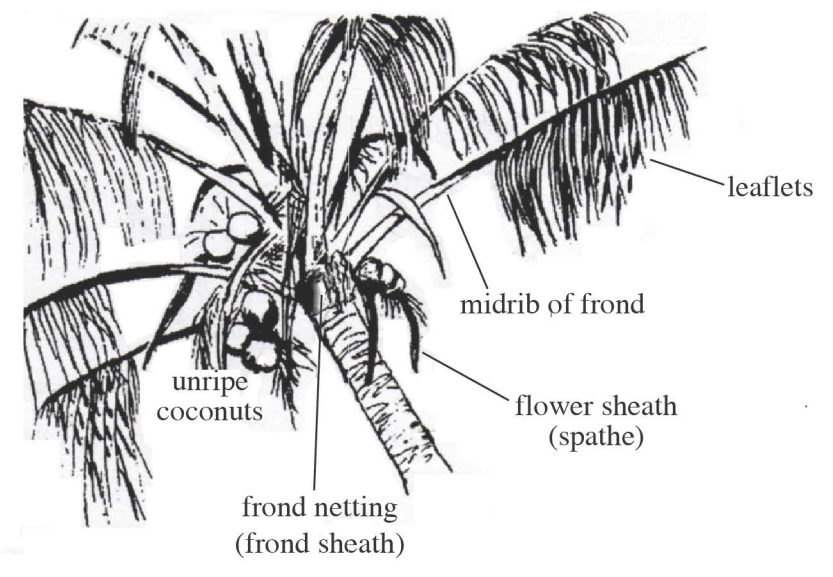

**Figure 12.2:** Parts of a coconut palm

Some parts of the palm are labelled with terms that are used for parts of plants in general. For example, Oceanic languages do not have a distinct name for the trunk of a coconut palm and nor presumably did POc. Instead, POc *puqu(n) ‘base of tree, source, origin’ (ch.4, §2.1) was apparently used, and the trunk of a coconut palm-and by metonymy the palm as a whole-was probably *puqun ni niuR (ch.2, §7.1.3). The coconut trunk is sometimes used for flooring and bearers, but it is difficult to trim and by no means the best material for these purposes (O’Collins & Lamothe 1989, Kwa’ioloa & Burt 2001: 192). The young leaf shoots of the coconut palm, which are sometimes eaten (French 1986: 31), have a distinct name only in Central Pacific languages (PCP *tō-rau, where the second element reflects POc *raun ’leaf; ch.4, §2.5, cf. Table 4.7), but are otherwise labelled with whatever term is used for leaf-shoots (ch.4, §2.6).

### 5.1. The frond and its parts

Coconut fronds are 4–6 m long and have a thick stalk (petiole) which narrows into a central spine or midrib (rachis) from which grow leaflets (pinnae) 60-90cm in length. Fronds serve as roofing material for shelters. Their leaflets are used to make baskets, and the dried ribs of the leaflets are bound together to make brooms.

As noted in ch.4, §2.5, Oceanic languages tend to have more than one term for the coconut frond, distinguishing between the green frond on the palm and the fallen, dried brown frond.

#### 5.1.1. Green fronds

Whether there was a single POc word denoting a green frond is debatable. Scattered languages use compounds meaning ‘leaf of coconut’ (Titan *lau-niw*, Anejom *neri-neañ*, Niuean *lau-niu*, each literally ‘leaf-coconut’ ) or ‘branch of coconut’ (Nehan *raŋ-kuen*, literally ‘branch-coconut’). There is thus some evidence for reconstructing *raun ni niuR ‘leaf of coconut’ and/or *raqan ni niuR ‘branch of coconut’.

Possible candidates for this meaning are POc *usiri and PWOc *pagal. However, the Tuam and Ramoaaina glosses of reflexes of *pagal suggest that it may have denoted the midrib of the frond or the broad base of the midrib. The Lihir reflex suggests that the denotation may have included palm fronds other than the coconut. The Vaghua, Varisi and Ririo reflexes are irregular in reflecting *-r-* for expected †*-l-* and in their denotation: ‘branch’. The meaning of POc *usiri is just as problematic.

| **POc** |  | *usiri | ‘palm frond or midrib of a frond’ (?) |
| --- | --- | --- | --- |
| MM | Nehan | *usiri* | ‘backbone; backbone of the small leaves of the coconut frond, sago palm, all palms’ |
| NCV | Paamese | *o-usil* | ‘frond’ |
| NCV | South Efate | *sēr* | ‘frond’ |

cf. also:

| PT | Iduna | *didi-na* | ‘coconut frond’ |
| --- | --- | --- | --- |

| **PWOc** |  | *pagal | ‘palm frond’ (?) |
| --- | --- | --- | --- |
| NNG | Kove | *paɣa-paɣa* | ‘coconut frond’ (A. Chowning, pers. comm.) |
| NNG | Tuam | *peleŋga-n* | ‘base of a coconut frond’ (metathesis) |
| NNG | Mangap | *(pal)paaŋga, (sul)paaŋga* | ‘palm frond’ |
| MM | Bulu | *pagal(i)* | ‘frond’ |
| MM | Lihir | *palaŋ* | ‘sago leaf’ |
| MM | Ramoaaina | *pagal* | ‘coconut leaf stem’ |

cf. also:

| MM | Vaghua | *pagar(a)* | ‘branch’ |
| --- | --- | --- | --- |
| MM | Varisi | *pagar(a)* | ‘branch’ |
| MM | Ririo | *pagar(eve)* | ‘branch’ |

Ross (1996d: 204) reconstructed POc *[pa]paq[a-], apparently denoting the frond of any palm. It reflects PMP *pa(q)paq ‘frond of a palm’ (Blust 1989). There is reasonable evidence that POc *[pa]paq[a-] occurred, but its meaning is unclear. Only the Arosi and Ellicean reflexes mean ‘palm frond’. Its Meso-Melanesian reflexes simply mean ‘leaf’, whilst its Polynesian reflexes imply that PPn *faʔa* meant the stalk of large leaves of various plants.

| **PMP** |  | *pa(q)paq | ‘frond of a palm’ (Blust 1989) |
| --- | --- | --- | --- |
| **POc** |  | *[pa]paq[a-] | ‘frond of a palm’ (?) (Ross 1996d) |
| MM | Bola | *paga* | ‘leaf’ |
| MM | Lavongai | *pa* | ‘leaf’ |
| MM | Kara (East) | *paka* | ‘leaf’ |
| MM | Kara (West) | *faka* | ‘leaf’ |
| MM | Nalik | *fəkə* | ‘leaf’ |
| MM | Tabar | *(paka)paka* | ‘leaf’ |
| MM | Sursurunga | *pəkə* | ‘leaf’ |
| MM | Patpatar | *paka* | ‘leaf’ |
| MM | Label | *paka* | ‘leaf’ |
| MM | Siar | *paka* | ‘leaf’ |
| MM | Teop | *paka* | ‘leaf’ |
| SES | Arosi | *haha-na* | ‘palm frond, branch of a palm or tree that has no branches, as sago palms, coconut, cycad, screw palm’ |
| Pn | Tongan | *faʔa* | ‘lower portion of leaf stalk of banana, taro, or giant taro (*Alocasia macrorrhiza*)’ |
| Pn | Niuean | *fā* | ‘(plant) stalk’ |
| Pn | Tikopia | *fā* | ‘leaf stem of fleshy plant’ |
| Pn | Rennellese | *haʔa* | ‘(taro, banana, papaya) stalk’ |
| Pn | Samoan | *fā* | ‘stalk, stem of taro, banana and certain other plants’ |
| Pn | Tuvalu | *fā* | ‘base end of a coconut midrib’ |
| Pn | Nukuoro | *hā* | ‘coconut palm frond’ |
| Pn | Hawaiian | *hā* | ‘stalk that supports the leaf and enfolds the stem of certain plants, as taro, sugarcane, layers in a banana stump’ |

#### 5.1.2. Dried fronds

One of the main uses of dry coconut fronds is as torches, and in a number of languages there is a polysemous term meaning ‘dry coconut leaf and’(coconut leaf) torch’ (e.g. Misima *wita* ‘(go) fishing with a lamp; dry coconut leaves; light made by burning dry coconut leaves’ and NE Ambae here ‘dry coconut leaf; dry coconut leaf lit and used as a torch’). Milke (1961) reconstructs *sulu(q) ‘dry coconut leaf torch’ for POc (see also vol.1, ch.6, §2.3). On the basis of the reflexes of this form it seems likely that as in the case of NE Ambae here, ‘dry coconut leaf’ was a secondary meaning. Thus, languages like Lukep, Ramoaaina, Uripiv, Mokilese and Tongan have reflexes with both meanings, and in other languages such as Longgu and Southeast Ambrym it is only the coconut leaf meaning which has been retained.

| **PMP** |  | *suluq | ‘torch’ (Dempwolff 1938) |
| --- | --- | --- | --- |
| **POc** |  | *sulu(q) | ‘dry coconut leaf torch; dry coconut leaf’ (Milke 1961) |
| Adm | Lou | *sula-n* | ‘dry coconut leaf’ |
| Adm | Titan | *cul* | ‘torch made from coconut fronds for scorching canoes or for fishing at night’ |
| NNG | Lukep (Pono) | *sul* | ‘dry coconut leaf; torch, traditionally made of dry coconut leaves’ |
| NNG | Takia | *sul* | ‘a torch made from dried coconut fronds’ |
| MM | Ramoaaina | *ulu* | ‘leaf of a coconut palm; coconut leaf or torch’ |
| SES | Longgu | *sulu* | ‘leaf, especially of coconut’ |
| NCV | Uripiv | *na-sul* | ‘coconut frond (especially a dry one); a light (the traditional use for dry coconut fronds)’ |
| NCV | Southeast Ambrym | *o-sil* | ‘coconut frond’ |
| NCV | Paamese | *(ou-i-)silu* | ‘coconut frond’ (ou ’leaf) |
| NCV | Nguna | *na-sulu* | ‘torch, flashlight, lamp, light’ |
| SV | Lenakel | *(nə-kou-i-)səl* | ‘coconut frond stalk’ |
| SV | Anejom̃ | *ni-sel* | ‘coconut leaf midrib’ |
| Mic | Kiribatese | *rin* | ‘dry coconut leaves used for torches’ |
| Mic | Mokilese | *til* | ‘dry coconut frond, torch’ |
| Fij | Rotuman | *sulu* | ‘coconut spathe; coconut spathe torch; fish by light of burning coconut spathe’ |
| Pn | Tongan | *hulu* | ‘dry coconut or banana leaves; show a light or give a light, with lantern or torch’ |
| Pn | Niuean | *hulu* | ‘torch (traditionally made of wooden fibres); to shine, give off light’ |

cf. also:

| Fij | Bauan | *suluka* | ‘dry leaves, generally of bananas for rolling cigarettes’ |
| --- | --- | --- | --- |
| Pn | Samoan | *sului* | ‘dry banana leaf (used as wrapper for a Samoan cheroolt); cheroot’ |

PWOc *daki had a similar meaning.

| **PWOc** |  | *daki | ‘dry coconut leaf torch’ |
| --- | --- | --- | --- |
| PT | Iduna | *daki* | ‘dry coconut leaf torch’ |
| MM | Susurunga | *dək* | ‘dry coconut leaf torch’ |

POc *ramaR ‘coconut leaf used as a torch when fishing’, reflecting PMP *damaR ‘resin, torch, light’, is also reconstructable (Ross 1996d: 205; vol.1, ch. 8, § 8).[^22] All reflexes indicate that this term denoted a torch - and specifically a torch used for fishing - rather just a coconut frond. The Lou and Tongan reflexes suggest that the *ramaR may also have been used as a verb.

| **PMP** |  | *damaR | ‘torch, light’ (Dempwolff 1938) |
| --- | --- | --- | --- |
| **POc** |  | *ramaR | ‘coconut leaf used as a torch when fishing’ (Capelll943) |
| Adm | Lou | *(ka)ram* | ‘torch’ |
| Adm | Lou | *ram-ram* | [v] ‘fish at night by torchlight’ |
| MM | Kara (East) | *lamak* | ‘coconut leafused as a torch’ |
| Fij | Bauan | *rama* | ‘cast light on’ |
| Fij | Bauan | *rama-rama* | ‘lamp of coconut shell filled with oil’ |
| Pn | Tongan | *ama* | [v] ‘fish at night by torch-light; torch made of coconut spathes bound together’ |
| Pn | Niuean | *ama* | ‘search for crabs, etc. with a torch’ |
| Pn | Tikopia | *rama* | [N] ‘torch of dry coconut frond’; [v] ‘fish with torches’ |
| Pn | Samoan | *lama* | ‘torch (made of dry coconut leaflets +); fishing with torches’ |
| Pn | Māori | *rama* | ‘torch; eeling with torches’ |

cf. also:

| PT | Misima | *dam* | ‘coconut leafused as a torch’ |
| --- | --- | --- | --- |

PWOc *bita appears to have the same range of meaning. Although there are only two known reflexes, the probability of a chance correspondence in form and meaning is so low that we can have reasonable confidence in the reconstruction.

| **PWOc** |  | *bita | ‘dry coconut frond, dry coconut frond torch; fish at night’ |
| --- | --- | --- | --- |
| PT | Misima | *wita* | ‘dry coconut leaves; light made by burning dry coconut leaves; (go) fishing with a lamp’ |
| MM | Nehan | *bita* | ‘dry coconut frond, dry coconut frond torch; fish at night’ |

#### 5.1.3. Midrib of the frond

Modern languages tend to have a distinctive term for the midrib or spine of a coconut frond, e.g. Iduna *domoluluna* ‘(main) stalk of coconut leaf’, Nduke *kilikava-* ‘stem of coconut frond, especially at thick end’, Wayan Fijian *bālotu* ‘a coconut frond stalk stripped of its leaflets; the stem of the coconut frond, used for firewood and torches’. There are two candidate terms for this meaning, POc *bala(p,b)a(q) and POc *sasaRi. Both may have denoted both the palm frond and the midrib - unsurprisingly, as a midrib is accompanied by its leaflets until they are stripped off.

| **PMP** |  | *p⟨al⟩a(q)paq | ‘midrib of coconut frond’ (Dempwolff 1925) |
| --- | --- | --- | --- |
| **POc** |  | *bala(p,b)a(q) | ‘palm branch; midrib of palm frond’ (Ross 1996d: *palapa(q)) |
| Adm | Loniu | *palapa* | ‘branch, especially of palm tree’ (for †*palaha*) |
| **PPn** |  | *palalafa | ‘stalk and midrib of a coconut frond’ (POLLEX) |
| Pn | Tongan | *palalafa* | ‘stalk (or stalk and midrib) of a coconut leaf’ |
| Pn | Emae | *pararafa* | ‘base of fallen coconut frond, still attached to tree’ |
| Pn | Pukapukan | *palelawa* | ‘midrib of coconut leaf’ |
| Pn | Tikopia | *pararafa* | ‘stem of coconut frond, used as small stirrer for liquids, tiny mallet in tattooing’ |

cf. also:

| Fij | Rotuman | *parafa* | ‘midrib of coconut leaf’ (loan from Polynesian) |
| --- | --- | --- | --- |

The Fijian reflex of *sasaRi makes the reconstruction of its meaning somewhat unsure.

| **POc** |  | *sasaRi | ‘midrib of coconut frond’ |
| --- | --- | --- | --- |
| NNG | Kove | *sasali* | ‘midrib’ |
| NNG | Bariai | *sasal* | ‘midrib’ |
| NNG | Mangap | *sasar* | ‘midrib of a coconut leaf’ |
| SES | Longgu | *sali-sali* | ‘rip a leaf along its midrib’ |

cf. also:

| Fij | Wayan | *sāsā* | ‘dry coconut frond’ |
| --- | --- | --- | --- |

#### 5.1.4. Spine/stalk of leaflet

Our sources often do not distinguish clearly between the frond and the leaflet (both are labelled ‘leaf’). The main use of coconut leaflets is that their dried spines are very commonly bound together to make brooms, and terms for the spine or stalk of leaflet typically relate to this use. Thus Manam *sinoka* ‘spine of coconut leaves, used for making brooms’, Ramoaaina *noko* ‘broom, coconut leaf spine’ and Carolinian sow ‘spine of the coconut leaf (used in weaving, making brooms)’. POc *no(k,g)o evidently denoted both the spines and the broom.

| **POc** |  | *no(k,g)o | ‘midrib or spine of coconut leaflet; broom made therefrom’ (Bender et al. 2003: 61) |
| --- | --- | --- | --- |
| NNG | Lukep (Pono) | *noŋ-noŋ* | ‘spine of a coconut leaflet’ |
| NNG | Sio | *noŋgo* | ‘centre strip of coconut leaf (used in brooms)’ |
| MM | Ramoaaina | *noko* | ‘midrib, small leaf stem; coconut leaf spine; broom’ |
| MM | Tolai | *noko* | ‘midrib of the leaflets of a coconut branch; broom, especiallly one made from these leaflets’ |
| **PMic** |  | *noko | ‘midrib of a coconut frond or leaf’ |
| Mic | Kiribatese | *noko* | ‘midrib of side leaves of coconut palm’ |
| Mic | Marshallese | *nᵚɔkʷ* | ‘midrib of a coconut leaf’ |
| Mic | Kosraean | *nɒk* | ‘midrib’ |
| Mic | Mokilese | *nok* | ‘coconut leaf midrib’ |

### 5.2. The frond netting

The protective netting at the base of the new coconut frond has the appearance of an open-weave cloth and is used in Oceanic societies for straining liquids, and particularly for wringing coconut ‘milk’ out of coconut flesh.

Two POc terms are reconstructable. The first, *kaka seems to have denoted the netting material itself, or perhaps the young frond within it. The second, *Runut, perhaps denoted the material in its function as a strainer.[^23] In vol.1 (ch.6, §5.6) a metathesised form *nuRut is also reconstructed on the basis of the Motu, Tolai and Mota reflexes. It is possible that this form did indeed occur, but it is also possible that metathesis occurred independently in two or three locations. Misima *lulusi* and Tawala *luluhi* are borrowings from a Suauic language like Saliba: the addition of *-i* after final consonants is unique to Suauic. These two forms and Saliba *lulusi* all display consonant assimilation (the expected Saliba form is †*lunusi*) and it is impossible to tell whether they reflect *Runut or *nuRut.

| **POc** |  | *kaka | ‘young coconut frond; coconut frond netting protecting young frond’ |
| --- | --- | --- | --- |
| MM | Patpatar | *kaka* | ‘new coconut frond that has not opened yet’ |
| NCV | North Efate | *kak* | ‘coconut mat, mesh formed by the coconut palm, used for straining liquids’ |
| NCV | South Efate | *kak* | ‘coconut mesh’ |
| **PPn** |  | *kaka | ‘clothlike fibre surrounding base of coconut fronds’ (POLLEX) |
| Pn | Tongan | *kaka* | ‘fibrous integument at the top of coconut palms’ |
| Pn | Niuean | *(lau)kaka* | ‘the fibrous wrapping round the base of a young coconut frond’ |
| Pn | Tikopia | *kaka* | ‘fibre of base of coconut palm (not sago palm) used traditionally to make filter sheet in turmeric extraction etc’ |
| Pn | East Futunan | *kaka* | ‘brown fibrous material that grows on coconut tree’ |
| Pn | Samoan | *ʔaʔa* | ‘coarse fibrous material found at the base of coconut leaves and used for strainers etc’ |
| Pn | Nukuoro | *gaga* | ‘fibrous sheathing (at the base of the petiole sheath of the flower) of the coconut tree’ |
| Pn | Tahitian | *ʔaʔa* | ‘brown fibrous membrane at base of coconut fronds; similar substance at base of leaves of sugarcane, bamboo and reeds’ |
| Pn | Hawaiian | *ʔa-ʔaʔa* | ‘coconut cloth, vascular bundles in taro corm, chaff; fibrous’ |

| **PMP** |  | *Runut | ‘plant fibres’ (Blust 1984) |
| --- | --- | --- | --- |
| **POc** |  | *Runut | ‘sheath around base of coconut frond, used as strainer’ (Ross 1996d: 203) |
| NNG | Gitua | *run* | ‘sheath around base of coconut frond, used as strainer’ |
| PT | Misima | *lulúsi* | ‘fine matting growing around base of coconut leaves, used as a sieve’ (Suauic borrowing) |
| PT | Tawala | *luluhi* | [N] ‘sheath around base of coconut frond’; [v] ‘strain, purify, improve’ (Suauic borrowing) |
| PT | Sariba | *lulusi* | ‘coconut tissue, used as a strainer’ |
| PT | Motu | *nuru* | ‘fibrous substance that grows around base of coconut frond; the stipule; coarse cloth; a sack’ (metathesis) |
| MM | Tolai | *nirut* | ‘leaf-root mesh of coconut tree’ (metathesis and vowell dissimilation) |
| NCV | Mota | *nir* | ‘fibrous spathe of coconut frond, used to strain sago’ (metathesis and vowel dissimilation) |
| NCV | Paamese | *(ä)un* | ‘cloth-like material at top of coconut tree’ |
| NCal | Pije | *uñ* | ‘fibrous spathe of coconut frond; husk of coconut’ |
| Mic | Kiribatese | *iŋ* | ‘fibre enveloping base of palm leaf and attaching it to the trunk, used as a filter’ |
| Mic | Puluwatese | *(ese) wɨn* | ‘coconut cloth’ |
| Mic | Ulithian | *ɨl* | ‘coconut cloth’ |
| Fij | Wayan | *unu* | ‘strainer for kava, in earlier times made of bark cloth, now usually muslin or any fine cloth’ |
| Pn | East Futunan | *unu* | ‘kava strainer made of bourao fibres’ |
| Pn | Samoan | *unu* | ‘woven wringer, used to extract dye from shreds of Bischofia tree bark etc’ |

### 5.3. The spathe, the inflorescence and the spadix

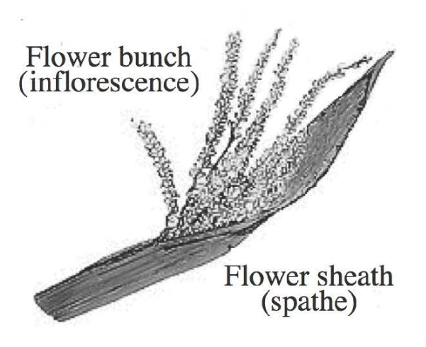

There was perhaps no separate term in most Oceanic languages for the inflorescence of the coconut. Some languages do have separate noncognate terms for coconut blossoms, e.g. Gapapaiwa *sisina*, Gumawana *niyola*, Misima *lámun*, Paamese *voha*, Anejom *nacomʷ*, but far fewer than have a term for ‘spathe’. Perhaps they were simply ‘flowers’, labelled by the general term POc *puŋa ‘flower, blossom’ (ch.4, §2.7).

Terms for the boat-shaped spathe, shown in Figure 12.3, and for the spadix (the branching flower stalk which becomes the stalk of a bunch of coconuts) are more common, although some languages do not distinguish between the two, whilst others have more than one term. The spathe is used for firewood and as a bowl or tray. Sugary sap can be tapped from the flower stalk (French 1986: 31). Sample terms are listed below. PPn had a term *loso-loso ‘coconut spadix; coconut spathe’ (POLLEX), reflected in most Polynesian languages.

| Adm | Titan | *páⁿrol* | ‘sheath of flower of the coconut palm, when dry; used as firewood’ |
| --- | --- | --- | --- |
| NNG | Numbami | *wawanziŋa* | ‘sheath over coconut blossoms (used as tray)’ |
| PT | Iduna | *lelewaka* | ‘(split) pod of coconut; covers kakaiyona’ |
| PT | Iduna | *kakaiyo-na* | ‘twigs, hand on which coconuts grow’ |
| PT | Tawala | *kena* | ‘sheath covering new coconut flowers’ |
| MM | Nduke | *rereto-* | ‘spathe of the coconut, the “boat” that accompanies the flowers and baby coconuts’ |
| MM | Nduke | *baɣutu-* | ‘stem that supports the flowers, and later the fruit, of the coconut’ |
| SES | Gela | *mbagona* | ‘spathe of coconut flowers’ |
| SES | Gela | *tu* | ‘spathe of coconut flowers’ |
| SES | Gela | *liliki* | ‘flower case of coconut’ |
| Fij | Wayan | *sāmoa* | ‘hard sheath or calyx enclosing flower of coconut (used as torch); coconut flower before sheath bursts’ |
| Pn | Tikopia | *taume* | ‘coconut spathe, when dry used for fuel’ |

The Wayan and Tikopia terms above reflect POc *jamu((q)a) which, however, evidently had the more general sense ‘cluster of flowers or fruit, usually palms’ (ch.4, §2. 8). If there was a dedicated POc term for the coconut spathe and/or spadix, we have been unable to reconstruct it.

## 6. Conclusion

The importance of the coconut in POc culture is attested - as we might expect - by a substantial collection of terms for its growth stages, especially for those that are salient to its consumers (green drinking coconut, ripe coconut with hardened flesh), for its parts (its water, its flesh and coconut cream/milk, the ‘apple’, the husk) and for certain parts of the palm (the frond and its midrib, the spines of the frond’s leaflets and the frond netting). Not surprisingly, some of these terms are inseparable from the functions for which they are used (shells and cups made from them; dried fronds, frond torches and torch fishing; leaflet spines and brooms; frond netting and strainers).

## Notes

[^1]: The English word ‘coconut’ is used here for both the palm and the fruit. The intended referent is, we hope, obvious from context.
[^2]: This section represents a re-run of the corresponding research reported in Ross (1996d) based on a larger range of data.
[^3]: In Lukep the term *matuk niu* denotes a green drinking coconut.
[^4]: The outer skin and husk are removed before export, so that coconuts sold in the shops of non-tropical countries consist of just the shell and its contents.
[^5]: Depending on one’s interpretation of the dictionary data.
[^6]: No further information on *pane uwa* is given by Codrington and Palmer.
[^7]: Churchward does not supply glosses for some terms. The gloss for *niu mata* is our inference.
[^8]: In Ross (1996d) this form was reconstructed with the stage 1 meaning of ‘coconut fruit bud’, but the sense common to the two reflexes implies a stage 2 gloss.
[^9]: A possible non-Oceanic cognate is Old Balinese *karu* ‘coconut shell’ (Modern Balinese *kau*).
[^10]: In NCV languages *R is sometimes reflected as zero, sometimes as a liquid. I am grateful to John Lynch for pointing out the Tape contrast and providing the data.
[^11]: PEMP *kupu is supported by a single non-Oceanic reflex, Numfor *uf* ‘round, yellow germination in a coconut’.
[^12]: Under plantation conditions a palm may bear up to 60 nuts a year. Palms may live up to 100 years, but their bearing capacity decreases towards zero in later life.
[^13]: In Ross (1996d) POc *polo was glossed ‘coconut water’, but the glosses of its reflexes make it more likely that it was a term for a drinking coconut, and so it is included here in §3.3.
[^14]: Verbs for removing the flesh from the shell are reconstructed in vol.1, ch.9, §3 .7, for scraping in vol.1, ch.9, §2.2.
[^15]: Productive nominalisations of reflexes of POc *kani ‘eat’ in Oceanic languages usually mean ‘staple food’ and by extension ‘food in general’ (ch.2, §6.1).
[^16]: Lynch (2001c) reconstructs PSV *nə-vutoy ‘brain’ with an unexpected initial *v- reflected in Anejom *h-*. Its resemblance to PAdm *puto- is probably accidental, as its reflexes only denote ‘brain’ and it is probably a reflex of POc *qutok in which PSV *v- (normally < POc *p-) is an idiosyncratic innovation.

    | SV | Anejom̃ | *n-hutu(ma)* | ‘brains’ |
    | --- | --- | --- | --- |
    | SV | North Tanna | *no-uta* | ‘brains’ |

[^17]: Terms for husking and breaking open a coconut are reconstructed in vol.1, ch.6, §5.5.
[^18]: The initial consonant of this form is irregular, as POc *p > *p* or *h* in Motu.
[^19]: It is not clear what the final *-ki* of Bauan *venuki* reflects.
[^20]: I am grateful to Jean Kennedy for this reference.
[^21]: The spathe is quite woody, and in parts of Asia fallen spathes are boiled, dried and waxed to produce boat-shaped bowls.
[^22]: In vol.1, ch.S, §8, the reconstructed form is *(d)rama(R), but initial *dr- (as opposed to *r-) is not required by the data. Final *-R* is apparently reflected in Kara *-k*. The usual Kara reflex of *-R is *-i*; *-k* is the normal reflex in neighbouring Tigak.
[^23]: vol.1, ch.6, §5.6, refers to the frond netting as the ‘spathe’ of the frond. Technically this is correct, but we prefer not to use the term here in order to avoid confusion with the spathe of the coconut flower (§5 .3).